# Final Project

Author

Kristy Feinberg

## Setup

```
here() starts at /Users/kristy/Desktop/Socio223
```

## 1. Introduction

In today’s society, the relationship between race and salary has become a focal point of discussions surrounding equity, diversity, and inclusion in the workplace. This statistical modeling assignment aims to examine the relationship between race and salary and interpret the underlying patterns and disparities.

To address this question, I used a data set from Kaggle that compiled information on gender, age, salary, years of experience, education level, and country. This data was last updated on November 1, 2023 and is expected to be updated annually. Although this data set includes countries such as UK, Canada, China, Australia, etc, I chose to focus only on US data.

Here’s a snapshot of the sample size and some key figures:

```
# A tibble: 5 × 6
  Country   count Mean_Salary SD_Salary Mean_Experience SD_Experience
  <chr>     <int>       <dbl>     <dbl>           <dbl>         <dbl>
1 USA        1356     112999.    51901.            7.83          5.83
2 China      1339     116283.    51760.            8.25          6.03
3 Australia  1335     114925.    53868.            7.94          6.05
4 UK         1332     115920.    53049.            8.24          6.15
5 Canada     1322     116455.    53448.            8.14          6.09
```

There were a total of 6684 observation and 9 different variables. Because the distribution of observations for all the countries appeared to be equally distributed, I felt it was acceptable to filter the countries to only contain observations from the US.

The data set indicates that the following integer values (0,1, 2, 3) correspond to different levels of education (High School, Bachelor’s, Master’s, Phd) respectively. For the readers sake, I will renaming these variables.

## 2. Exploratory data analysis

```
# A tibble: 4 × 8
  Race    count Senior Mean_Salary Median_Salary SD_Salary Min_Salary Max_Salary
  <chr>   <int>  <int>       <dbl>         <dbl>     <dbl>      <dbl>      <dbl>
1 Africa…   352     49     112355.        110000    50700.      25000     220000
2 White     347     46     115764.        115000    53377.      25000     240000
3 Asian     335     37     113299.        114776    49944.        500     219000
4 Hispan…   322     44     110410.        105000    53649.        350     225000
```

The purpose of generating this summary table was to find the total count of observations and Seniors within each race. This was a test for my own sake to make sure we weren’t removing too many factors and didn’t have a significant amount, or distribution, remaining.

```
# A tibble: 72 × 3
   `Job Title`               count Mean_Salary
   <chr>                     <int>       <dbl>
 1 Software Engineer           167     119698.
 2 Data Scientist               99     158424.
 3 Data Analyst                 81     122321.
 4 Software Engineer Manager    73     170070.
 5 Product Manager              72     143208.
 6 Marketing Manager            64     108750
 7 Project Engineer             59     161640.
 8 Full Stack Engineer          57     127459.
 9 Back end Developer           56     102787.
10 Front end Developer          56      83388.
# ℹ 62 more rows
```

Before beginning our analysis it’s important to have an understanding of what types of jobs are represented within our sample. It can be helpful in understanding the distribution of salaries and potential biases. The above table shows us that US observations were skewed towards Data and Tech heavy Jobs such as Engineering, Programming, and Data Science.

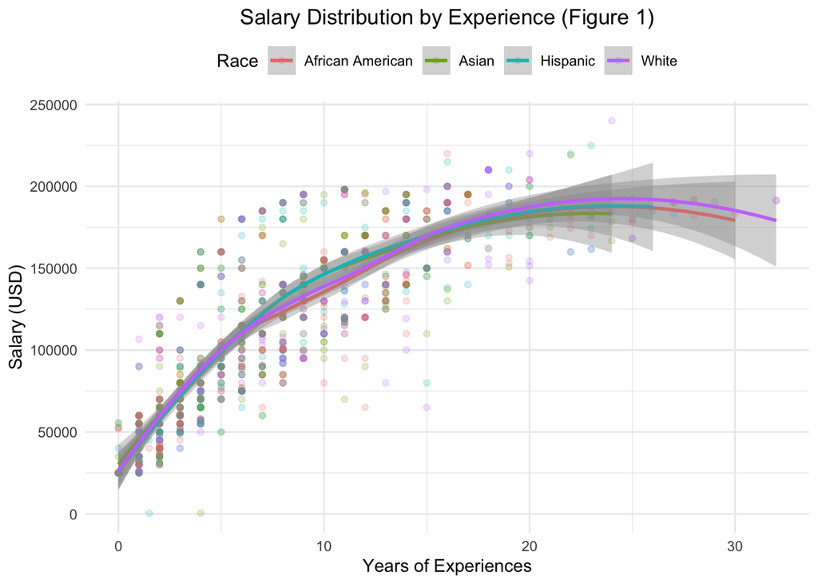

The highest salaries, on average, appear to occur when an individual has approximately 25 years of experience. After 25 years, we see a downward sloping relationship between one additional year of experience and salary. This could be explained by people making high salaries exiting the job market when they have enough savings and retiring. This would drive down the mean salary we see individuals with years of experience making.

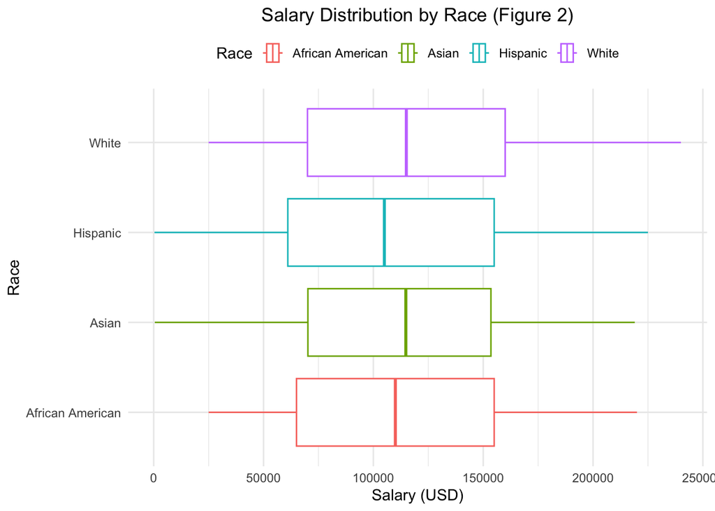

Looking at Figure 2, which displays the relationship between our numerical outcome variable Salary and our categorical explanatory variable Race, the Salary amounts look to be the greatest for people from Asian ($113,299) or White ($115,763.8) heritage and the smallest for people from Hispanic ($110,410.1) or African American ($112,355.3) heritage, though the difference does not seem to be extreme. Furthermore, there do not seem to be significant outliers.

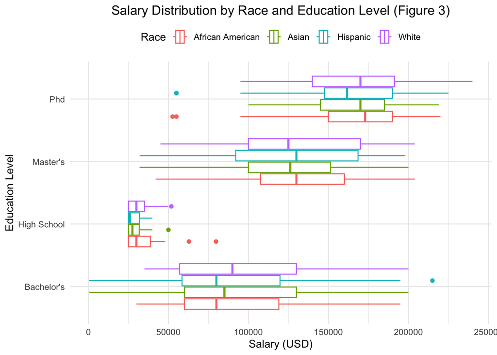

## 3. Multiple linear regression

### 3.1 Methods

The components of our multiple linear regression model are the following:

- Outcome variable y = Salary
- Numerical explanatory variables = Years of Experience, Age
- Categorical explanatory variables = Gender, Race, Education Level, Senior

### 3.2 Model Results

For the purpose of the linear regression, I designed the regression, using relevel, so that “White” becomes the reference level. In regression analysis, choosing a reference level can be important for interpreting coefficients. By releveling, I am setting “White” as the baseline or reference group, and the coefficients for other race categories will be compared to this reference group.

```r
m1 <- lm(Age ~ `Years of Experience`, data = salary_us)

glance(m1)
```

```
# A tibble: 1 × 12
  r.squared adj.r.squared sigma statistic p.value    df logLik   AIC   BIC
      <dbl>         <dbl> <dbl>     <dbl>   <dbl> <dbl>  <dbl> <dbl> <dbl>
1     0.887         0.886  2.47    10579.       0     1 -3146. 6299. 6315.
# ℹ 3 more variables: deviance <dbl>, df.residual <int>, nobs <int>
```

An r^2 of 0.8865288 is a bit concerning. This means that age and years of experience are highly correlated. For the simplicity of our model, and to eliminate competing forces, we will exclude Age from our regression.

### 3.3 Confidence Intervals

```r
linear_model <- lm(Salary ~ Race, salary_us)

tidy(linear_model)
```

```
# A tibble: 4 × 5
  term                 estimate std.error statistic   p.value
  <chr>                   <dbl>     <dbl>     <dbl>     <dbl>
1 (Intercept)           115764.     2787.    41.5   1.10e-243
2 RaceAfrican American   -3409.     3928.    -0.868 3.86e-  1
3 RaceAsian              -2465.     3977.    -0.620 5.36e-  1
4 RaceHispanic           -5354.     4018.    -1.33  1.83e-  1
```

Based on the above linear model we get an equation that looks like this…

$$\hat{y} = b_0 +b_1x_1+b_2x_2+b_3x_3$$

$$\hat{Salary}= 115763.793 - 3408.508*(African American)-2464.822(Asian)-5353.653(Hispanic)$$

Keeping all else constant, the base salary (reference group = White) is $115,763.793.

- If an individual is African American, their salary is estimated to be reduced by $3,408.508 compared to the reference group.
- If an individual is Asian, their salary is estimated to be reduced by $2,464.822 compared to the reference group.
- If an individual is Hispanic, their salary is estimated to be reduced by $5,353.653 compared to the reference group.

```r
confint(linear_model, level=0.95)
```

```
                         2.5 %     97.5 %
(Intercept)          110295.70 121231.883
RaceAfrican American -11114.05   4297.030
RaceAsian            -10266.81   5337.170
RaceHispanic         -13235.37   2528.064
```

What is important to note in these findings is that the 95% confidence interval for African American [-11114.05, 4297.030]. This means we are 95% confident that the true population value of the coefficient for African American race falls within this range. Since the interval includes 0, it suggests that the effect of being African American on salary is not statistically significant at the 5% significance level. Because the confidence intervals for Asians and Hispanics also include 0, it suggests that these variable may not be a significant predictor of the outcome variable, Salary. Statistical significance is determined by whether the interval excludes 0 or not. If the interval includes 0, it indicates that the estimate is not significantly different from 0.

### 3.4 Testing Multiple Linear Regressions

```r
model1 <- lm(Salary ~ (Gender + `Years of Experience` + I(`Years of Experience`^2) + Senior + `Education Level`)*Race, data = salary_us)

get_regression_table(model1)
```

```
# A tibble: 32 × 7
   term                   estimate std_error statistic p_value lower_ci upper_ci
   <chr>                     <dbl>     <dbl>     <dbl>   <dbl>    <dbl>    <dbl>
 1 intercept                41575.    3896.     10.7     0       33931.   49218.
 2 Gender: Male              3339.    3002.      1.11    0.266   -2550.    9228.
 3 `Years of Experience`    11548.     822.     14.1     0        9936.   13160.
 4 I(`Years of Experienc…    -236.      29.6    -7.96    0        -294.    -178.
 5 Senior                  -14544.    4380.     -3.32    0.001  -23137.   -5951.
 6 `Education Level`High…  -24273.    6095.     -3.98    0      -36230.  -12317.
 7 `Education Level`Mast…    7747.    3786.      2.05    0.041     320.   15173.
 8 `Education Level`Phd     16231.    4678.      3.47    0.001    7054.   25407.
 9 Race: African American   -1721.    5595.     -0.308   0.758  -12696.    9255.
10 Race: Asian              -5672.    5804.     -0.977   0.329  -17058.    5713.
# ℹ 22 more rows
```

### 3.5 Hypothesis Testing

Using the output of our regression table we’ll test our null hypotheses.

$$\text{Null Hypothesis } (H_0) : \text{there is parallel difference in Salary across different Races}$$

$$\text{(the complex model is no better than the simple model)}$$

$$\text{Alternative Hypothesis } (H_a) : \text{the other varables in this regression differ by each race}$$

```r
model2 <- lm(Salary ~  Gender + `Years of Experience` + I(`Years of Experience`^2) + Senior + `Education Level` + Race, data = salary_us)

tidy(model2, conf.int = TRUE)
```

```
# A tibble: 11 × 7
   term                estimate std.error statistic   p.value conf.low conf.high
   <chr>                  <dbl>     <dbl>     <dbl>     <dbl>    <dbl>     <dbl>
 1 (Intercept)           39050.    2370.     16.5   1.03e- 55   34402.    43699.
 2 GenderMale             5162.    1480.      3.49  5.03e-  4    2258.     8065.
 3 `Years of Experien…   12150.     433.     28.0   1.22e-136   11300.    13000.
 4 I(`Years of Experi…    -267.      17.1   -15.6   1.60e- 50    -300.     -233.
 5 Senior               -11286.    2246.     -5.03  5.70e-  7  -15692.    -6881.
 6 `Education Level`H…  -21892.    3265.     -6.71  2.94e- 11  -28296.   -15488.
 7 `Education Level`M…    5574.    1924.      2.90  3.82e-  3    1801.     9348.
 8 `Education Level`P…   16010.    2401.      6.67  3.76e- 11   11300.    20720.
 9 RaceAfrican Americ…   -1831.    1992.     -0.919 3.58e-  1   -5738.     2076.
10 RaceAsian               884.    2026.      0.436 6.63e-  1   -3092.     4859.
11 RaceHispanic           -253.    2041.     -0.124 9.01e-  1   -4257.     3751.
```

$$\hat{Salary}= 39050 + 5162(Male) + 12150(Yrs Expereience) -267(Yrs Expereience)^2$$

$$-11286(Senior) - 21892(High School) + 5574(Master's) + 16010(Phd)$$

$$- 1831(African American) + 884(Asian) - 253(Hispanic)$$

This equation allows you to predict the salary for an individual based on their gender, years of experience, seniority, education level, and race. Each coefficient represents the estimated change in salary associated with a one-unit change in the corresponding predictor variable, holding other variables constant.

```r
anova(model1,model2)
```

```
Analysis of Variance Table

Model 1: Salary ~ (Gender + `Years of Experience` + I(`Years of Experience`^2) +
    Senior + `Education Level`) * Race
Model 2: Salary ~ Gender + `Years of Experience` + I(`Years of Experience`^2) +
    Senior + `Education Level` + Race
  Res.Df        RSS  Df   Sum of Sq      F Pr(>F)
1   1324 9.1455e+11
2   1345 9.3025e+11 -21 -1.5691e+10 1.0817  0.361
```

The Analysis of Variance (ANOVA) table comparing two models to assess whether there are statistically significant differences between the models. The models are being compared using the F-statistic, which is a ratio of the explained variance to the unexplained variance.

The p-value tells one how likely the data observed is to have occurred under the null hypothesis. A p-value below one’s threshold of significance, typically p<0.05, indicates strong evidence against the null hypothesis. The p-value (0.361) is higher than the assigned threshold of significance of 0.05. This suggests that there is not enough evidence to reject the null hypothesis that the additional variables in Model 1 (the interactions of each variable with Race) do not significantly improve the fit of the model compared to Model 2 (the additive model).

```r
## the AIC (Akaike's Information Criterion) is AIC = N*log(RSS/N) + 2k
## choosing the lowest is generally a reasonable idea

AIC(model1,model2)
```

```
       df      AIC
model1 33 31480.84
model2 12 31461.91
```

The AIC function is used to measure of the relative quality of statistical models. The lower AIC values indicating a better-fitting model, while also considering the trade-off between the goodness of fit and the complexity of the model. With these results we can pick the model with the lowest AIC. Model 2 has a lower AIC (31461.91) compared to Model 1 (31480.84). In the context of our results, lower values indicate a better fit, so Model 2 (the additive model) is preferred over Model 1.

## 4. Discussion

### 4.1 Conclusion

In the context of our data, Race does not seem to be a significant factor in explaining the variation in the dependent variable or its interactions with other independent variables such as Salary. There is **no** significant difference in Salary across different racial groups, as shown by our confidence intervals of the linear model. Furthermore, there is **no** evidence of interactions between the variables of interest (Gender, Years of Experience, Senior, Education Level) and race that would create a more complex relationship, as shown by the annova and AIC calculations.

```
  Gender Years of Experience Senior Education Level  Race Predicted_Salary
1   Male                   0      1      Bachelor's White         32926.13
2   Male                   2      1      Bachelor's White         56159.88
3   Male                   4      1      Bachelor's White         77259.71
4   Male                   6      1      Bachelor's White         96225.62
5   Male                   8      1      Bachelor's White        113057.62
```

The above table shows the first 5 entries for a new data frame using Model 2 to make predictions about predicted salary. I controlled for Male, Senior, Bachelor’s, and allowed Years of Experience and Race to vary. I included predictions for people of White and African American heritage and their predicted salaries given different years of experience.

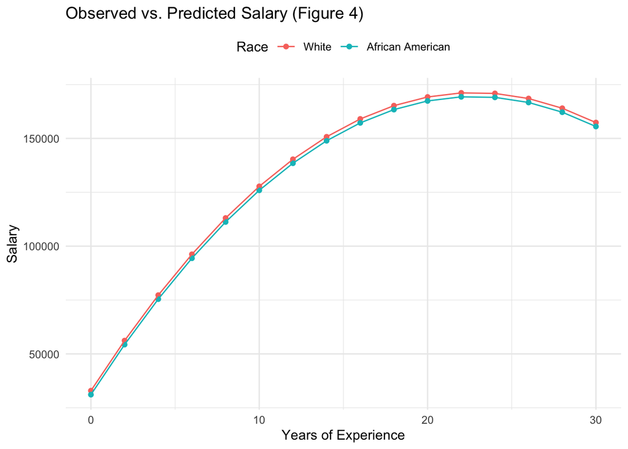

The plot above, Figure 4, is a visualization of the relationship between predicted salary and years of experience for people from White and African American heritages, controlling for all other variables. Each point on the plot represents an prediction based on our regression, Model 2 (additive model). The color of the point represents the race of the individual and the lines connecting the points represent the trend in predicted salaries based on our regression model. This is consistent with our findings of how the model expects salaries to change with increasing years of experience but does not vary significantly for each race.

### 4.3 Further Questions

While our current analysis provides valuable insights into the relationship between Race and Salary, considering various factors such as Education Level, Years of Experience, Seniority, and Gender. Moving forward, we could consider exploring additional research questions that could build on this analysis. One such topic could be an industry specific analysis of whether certain sectors or professions exhibit distinct patterns in the relationship between race and compensation. Furthermore, one might find it interesting to take a deep dive into company policies to analyze the impact of diversity and inclusion initiatives that might contribute to or mitigate salary differences. It could also be telling to consider how family structure, marital status, and/or other demographic factors influence the relationship between Race and Salary.

## 5. References & Sources

https://www.kaggle.com/datasets/amirmahdiabbootalebi/salary-by-job-title-and-country

https://moderndive.com/index.html